# Image processing and classification

### Tutors: Juha Mehtonen, Trung Ngo Trong

## Loading libraries and dataset

```python
%matplotlib inline
from __future__ import print_function, absolute_import, division
import matplotlib
matplotlib.use('Agg')
from matplotlib import pyplot as plt
from IPython.core.pylabtools import figsize
figsize(12, 6)

import os
import sys

from scipy.stats import itemfreq
import numpy as np
np.random.seed(1208)

from utils import (rotate, shift, zoom, shear, one_hot, cifar_labels,
                   plot_hist)

from keras.utils import Progbar
from keras.models import Sequential
from keras.layers import Dense, Dropout, Reshape
from keras.layers import Conv2D, MaxPooling2D, Flatten
from keras.optimizers import RMSprop
```

What do we need for this task:

- **numpy and scipy**: for loading images and matrix manipulation
- **utils**: for some shortcuts to images transformation
- **keras**: powerful neural network library for training the classifier

## Constants

Setting the amount of training, validating, and testing data here

```python
NB_OF_VISUALIZATION = 25
TRAINING_PORTION = 0.5
VALID_PORTION = 0.2
```

## Loading and visualize the MNIST dataset

```
MNIST shapes: (30000, 28, 28, 1) (30000,)
```

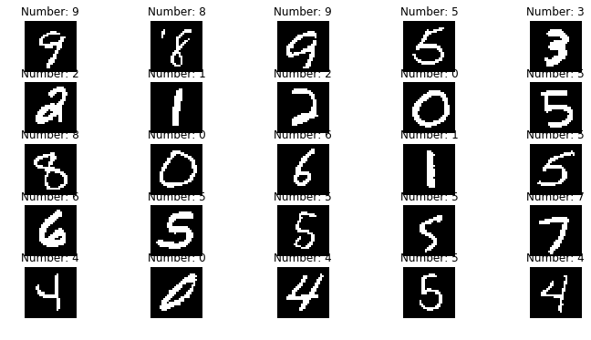

```python
x = np.load('MNIST_x.npy')
y = np.load('MNIST_y.npy')
print("MNIST shapes:", x.shape, y.shape)

# ====== visualize the data ====== #
fig = plt.figure()
labels = ''
n = int(np.sqrt(NB_OF_VISUALIZATION))
for i in range(NB_OF_VISUALIZATION):
    ax = plt.subplot(n, n, i + 1)
    ax.axis('off')
    # plot grey scale image require 2D array
    plt.imshow(x[i][:, :, 0], cmap=plt.cm.Greys_r)
    ax.set_title("Number: %d" % y[i])
```

What can we see from the images?

- The image is grayscale, binary photos(i.e. features are 0 or 1)
- Not much rotation or translation appeared to different images from the same digit
- The labels are matched with the images, hence, the provided dataset is clean and sound

## Augmentation images for training

Since only *50 %* of the dataset is used for training, it is good idea to perform data augmentation ?

The idea of data augmentation is:

> > > Increasing the amount of data by introducing noise, or transformation to original images to create a more robust dataset.

There are four basic image transformation can be applied:

- Rotation
- Translation(shift)
- Zooming
- Shearing

All are visualized by following figures.

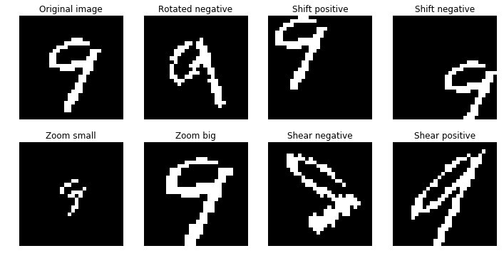

```python
img = x[0]

fig = plt.figure()
ax = plt.subplot(2, 4, 1)
ax.imshow(img[:, :, 0], cmap=plt.cm.Greys_r)
ax.axis('off')
ax.set_title('Original image')

ax = plt.subplot(2, 4, 2)
ax.imshow(rotate(img, 45)[:, :, 0], cmap=plt.cm.Greys_r)
ax.axis('off')
ax.set_title('Rotated positive')

ax = plt.subplot(2, 4, 2)
ax.imshow(rotate(img, -45)[:, :, 0], cmap=plt.cm.Greys_r)
ax.axis('off')
ax.set_title('Rotated negative')

ax = plt.subplot(2, 4, 3)
ax.imshow(shift(img, 0.2, 0.2)[:, :, 0], cmap=plt.cm.Greys_r)
ax.axis('off')
ax.set_title('Shift positive')

ax = plt.subplot(2, 4, 4)
ax.imshow(shift(img, -0.2, -0.2)[:, :, 0], cmap=plt.cm.Greys_r)
ax.axis('off')
ax.set_title('Shift negative')

ax = plt.subplot(2, 4, 5)
ax.imshow(zoom(img, 2, 2)[:, :, 0], cmap=plt.cm.Greys_r)
ax.axis('off')
ax.set_title('Zoom small')

ax = plt.subplot(2, 4, 6)
ax.imshow(zoom(img, 0.8, 0.8)[:, :, 0], cmap=plt.cm.Greys_r)
ax.axis('off')
ax.set_title('Zoom big')

ax = plt.subplot(2, 4, 7)
ax.imshow(shear(img, 0.8)[:, :, 0], cmap=plt.cm.Greys_r)
ax.axis('off')
ax.set_title('Shear negative')

ax = plt.subplot(2, 4, 8)
ax.imshow(shear(img, -0.8)[:, :, 0], cmap=plt.cm.Greys_r)
ax.axis('off')
ax.set_title('Shear positive')
```

## Data splitting for training classifiers

We are interested in the generalization ability of the model to new data, it is important to create reliable datasets for evaluating this criterion.

Since the model is fitted on training set, the performance on training data is trivial. As a result, we split the dataset into 3 partitions:

- Training set
- Validating set: for model selection, hyper - parameters fine tuning.
- Testing set: for final evaluation of the model, since the model has never seen those data, its performance is closest to the generalization ability

```python
permutation = np.random.permutation(len(x))
x = x[permutation]
y = y[permutation]

nb_train = int(TRAINING_PORTION * len(x))
nb_valid = int(VALID_PORTION * len(x))
nb_test = len(x) - nb_train - nb_valid

x_train = x[:nb_train]
y_train = y[:nb_train]

x_valid = x[nb_train:nb_train + nb_valid]
y_valid = y[nb_train:nb_train + nb_valid]

x_test = x[nb_train + nb_valid:]
y_test = y[nb_train + nb_valid:]
```

Another important note is that we only perform augmentation on training data, followed by this code:

```python
# ====== augmenting the training data ====== #
augment_function = [lambda img: shift(img, 0.1, -0.2),
                    lambda img: rotate(img, 45)]
# apply on out data
x_new = []
y_new = []
prog = Progbar(target=len(x_train))
for i in range(len(x_train)):
    x_new += [x_train[i]] + [f(x_train[i]) for f in augment_function]
    y_new += [y_train[i]] * (1 + len(augment_function))
    prog.update(i)
prog.update(len(x_train))
x_aug = np.array(x_new)
y_aug = np.array(y_new)
```

It is critical to validate our splitting strategy. The algorithm must assure that the splitting process doesn't create any bias in training dataset, which can be checked by visualizing the distribution of the true dataset.

```
Train set: (15000, 28, 28, 1) (15000,)
Valid set: (6000, 28, 28, 1) (6000,)
Test set: (9000, 28, 28, 1) (9000,)
Augmented training set: (45000, 28, 28, 1) (45000,)
```

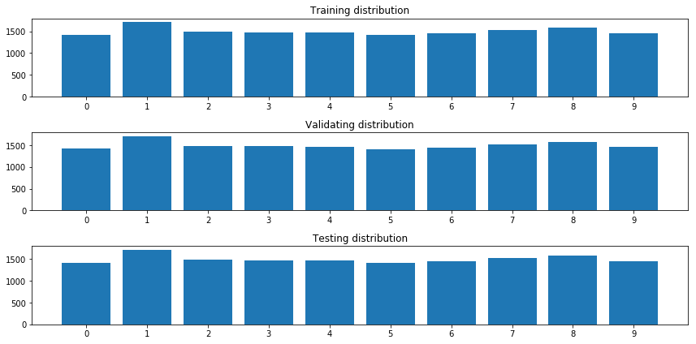

```python
print("Train set:", x_train.shape, y_train.shape)
print("Valid set:", x_valid.shape, y_valid.shape)
print("Test set:", x_test.shape, y_test.shape)
print("Augmented training set:", x_aug.shape, y_aug.shape)
# ====== checking distribution of train, valid, test matching ====== #
train_dist = itemfreq(y_train)
valid_dist = itemfreq(y_valid)
test_dist = itemfreq(y_test)

plt.figure()
ax = plt.subplot(3, 1, 1)
plot_hist(y_train, ax, "Training distribution")
ax = plt.subplot(3, 1, 2)
plot_hist(y_train, ax, "Validating distribution")
ax = plt.subplot(3, 1, 3)
plot_hist(y_train, ax, "Testing distribution")
plt.tight_layout()
```

## Training digit classifier

Most of machine learning algorithm require the labels to be one - hot encoded, which is visualized by following code:

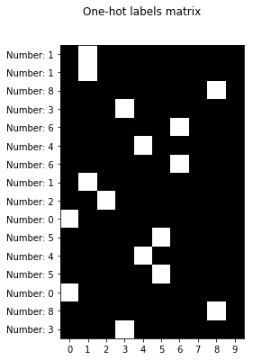

```python
# ====== convert labels to one_hot for training ====== #
labels = ["Number: %d" % i for i in y_train[:16]]
y_train = one_hot(y_train, nb_classes=10)
y_aug = one_hot(y_aug, nb_classes=10)
y_test = one_hot(y_test, nb_classes=10)
y_valid = one_hot(y_valid, nb_classes=10)
plt.figure()
plt.imshow(y_train[:16], cmap=plt.cm.Greys_r)
plt.xticks(np.arange(10))
plt.yticks(np.arange(16), labels)
plt.suptitle("One-hot labels matrix")
```

### Creating neural network classifier with keras

The following function create a neural network, which output 10 probability values(i.e. softmax output) to represent the confident of given image for 10 different digits.

The network is trained on **(x_train, y_train)**, validated on **(x_valid, y_valid)**, and finally evaluated using **(x_test, y_test)**

```python
def train_and_test_dnn(x_train, y_train,
                       x_valid, y_valid,
                       x_test, y_test,
                       title):
    input_shape = x_train.shape[1:]
    model = Sequential()
    model.add(Reshape(target_shape=(np.prod(input_shape),),
                      input_shape=input_shape))
    model.add(Dense(256, activation='relu'))
    model.add(Dropout(0.2))
    model.add(Dense(10, activation='softmax'))
    #showing the network configuration
    model.summary()

    model.compile(loss='categorical_crossentropy',
                  optimizer=RMSprop(),
                  metrics=['accuracy'])

    history = model.fit(x_train, y_train,
                        batch_size=128,
                        epochs=5,
                        verbose=1,
                        validation_data=(x_valid, y_valid))
    # ====== plot history ====== #
    plt.figure()
    plt.subplot(1, 2, 1)
    train_loss = history.history['loss']
    val_loss = history.history['val_loss']
    plt.plot(train_loss, color='b', label='Training loss')
    plt.plot(val_loss, color='r', label="Validing loss")
    plt.suptitle(title + "(cross-entropy loss)")
    plt.legend()
    plt.subplot(1, 2, 2)
    train_loss = history.history['acc']
    val_loss = history.history['val_acc']
    plt.plot(train_loss, color='b', label='Training Accuracy')
    plt.plot(val_loss, color='r', label="Validing Accracy")
    plt.suptitle(title + "(Accuracy)")
    plt.legend()
    # ====== final evaluation ====== #
    score = model.evaluate(x_test, y_test, verbose=0)
    print('Test loss:', score[0])
    print('Test accuracy:', score[1])
    return history
```

We first train the model on original MNIST training set:

```
_________________________________________________________________
Layer (type)                 Output Shape              Param #
=================================================================
reshape_5 (Reshape)          (None, 784)               0
_________________________________________________________________
dense_13 (Dense)             (None, 256)               200960
_________________________________________________________________
dropout_7 (Dropout)          (None, 256)               0
_________________________________________________________________
dense_14 (Dense)             (None, 10)                2570
=================================================================
Total params: 203,530
Trainable params: 203,530
Non-trainable params: 0
_________________________________________________________________
Train on 15000 samples, validate on 6000 samples
Test loss: 0.180460752992
Test accuracy: 0.946111111111
```

```
<keras.callbacks.History at 0x14ab21bd0>
```

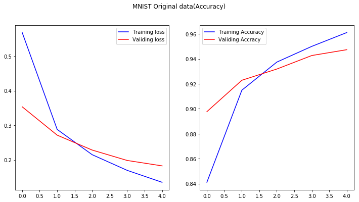

```python
train_and_test_dnn(x_train, y_train, x_valid, y_valid, x_test, y_test,
    'MNIST Original data')
```

The model summary and learning curves are also procedure, we can use this information for diagnose the training process.

Let see if the augmented dataset really help in this case:

```
_________________________________________________________________
Layer (type)                 Output Shape              Param #
=================================================================
reshape_6 (Reshape)          (None, 784)               0
_________________________________________________________________
dense_15 (Dense)             (None, 256)               200960
_________________________________________________________________
dropout_8 (Dropout)          (None, 256)               0
_________________________________________________________________
dense_16 (Dense)             (None, 10)                2570
=================================================================
Total params: 203,530
Trainable params: 203,530
Non-trainable params: 0
_________________________________________________________________
Train on 45000 samples, validate on 6000 samples
Test loss: 0.180518824976
Test accuracy: 0.945
```

```
<keras.callbacks.History at 0x14ba9b8d0>
```

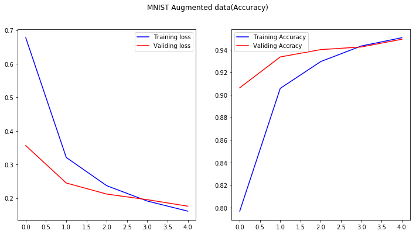

```python
train_and_test_dnn(x_aug, y_aug, x_valid, y_valid, x_test, y_test,
    'MNIST Augmented data')
```

Why the augmented data doesn't work out?

- The data is simple and there are no complicated transformations.
- The amount of training data is significantly increased, hence, it probably require more powerful network to learn additional representation.

## What about colored images?

We useCIFAR - 10 dataset for simulating similar approach to colored images.

The original CIFAR - 10 dataset consists of 60000 32x32 colour images in 10 classes, with 6000 images per class. There are 50000 training images and 10000 test images.

The data in this example is 15000 randomly selected images from CIFAR - 10. The ten categories are:

- airplane
- automobile
- bird
- cat
- deer
- dog
- frog
- horse
- ship
- truck

Load and visualize the dataset:

```
CIFAR shapes: (15000, 32, 32, 3) (15000,)
```

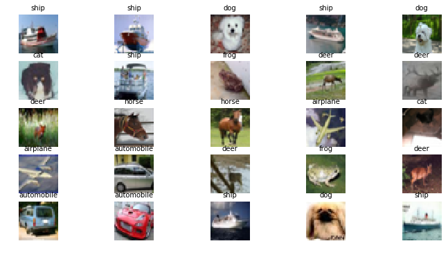

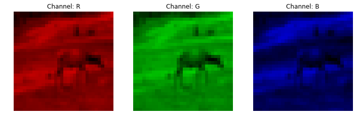

```python
x = np.load('CIFAR_x.npy')
y = np.load('CIFAR_y.npy')
print("CIFAR shapes:", x.shape, y.shape)

# ====== visualize the data ====== #
fig = plt.figure()
labels = ''
n = int(np.sqrt(NB_OF_VISUALIZATION))
for i in range(NB_OF_VISUALIZATION):
    ax = plt.subplot(n, n, i + 1)
    ax.axis('off')
    # plot grey scale image require 2D array
    plt.imshow(x[i])
    ax.set_title(cifar_labels[y[i]], fontsize=10)

# ====== plot differnt channel ====== #
fig = plt.figure()
sample_img = x[8]
title = ['R', 'G', 'B']
for i in range(3):
    temp = np.zeros(sample_img.shape, dtype='uint8')
    temp[:, :, i] = sample_img[:, :, i]
    ax = plt.subplot(1, 3, i + 1)
    ax.imshow(temp)
    ax.set_axis_off()
    ax.set_title("Channel: " + title[i])
```

### Data preparation and splitting

We repeat the same process applied for MNIST

```python
# ====== again split train, test, valid ====== #
# shuffle the data, note the order of x and y must match
permutation = np.random.permutation(len(x))
x = x[permutation]
y = y[permutation]

nb_train = int(TRAINING_PORTION * len(x))
nb_valid = int(VALID_PORTION * len(x))
nb_test = len(x) - nb_train - nb_valid

x_train = x[:nb_train]
y_train = y[:nb_train]

x_valid = x[nb_train:nb_train + nb_valid]
y_valid = y[nb_train:nb_train + nb_valid]

x_test = x[nb_train + nb_valid:]
y_test = y[nb_train + nb_valid:]

# ====== augmenting the training data ====== #
augment_function = [lambda img: shift(img, 0.1, -0.2),
                    lambda img: rotate(img, 45)]
# apply on out data
x_new = []
y_new = []
prog = Progbar(target=len(x_train))
for i in range(len(x_train)):
    x_new += [x_train[i]] + [f(x_train[i]) for f in augment_function]
    y_new += [y_train[i]] * (1 + len(augment_function))
    prog.update(i)
prog.update(len(x_train))
x_aug = np.array(x_new)
y_aug = np.array(y_new)

# ====== print info ====== #
print("Train set:", x_train.shape, y_train.shape)
print("Augmented set:", x_aug.shape, y_aug.shape)
print("Valid set:", x_valid.shape, y_valid.shape)
print("Test set:", x_test.shape, y_test.shape)
print("Augmented training set:", x_aug.shape, y_aug.shape)

# ====== convert labels to one_hot for training ====== #
y_train = one_hot(y_train, nb_classes=10)
y_aug = one_hot(y_aug, nb_classes=10)
y_test = one_hot(y_test, nb_classes=10)
y_valid = one_hot(y_valid, nb_classes=10)
```

[output not shown]

### Training classifier

Again, we apply the same network for CIFAR dataset:

```
_________________________________________________________________
Layer (type)                 Output Shape              Param #
=================================================================
reshape_7 (Reshape)          (None, 3072)              0
_________________________________________________________________
dense_17 (Dense)             (None, 256)               786688
_________________________________________________________________
dropout_9 (Dropout)          (None, 256)               0
_________________________________________________________________
dense_18 (Dense)             (None, 10)                2570
=================================================================
Total params: 789,258
Trainable params: 789,258
Non-trainable params: 0
_________________________________________________________________
Train on 7500 samples, validate on 3000 samples
Test loss: 14.6710487595
Test accuracy: 0.0897777778043
```

```
<keras.callbacks.History at 0x1338c7990>
```

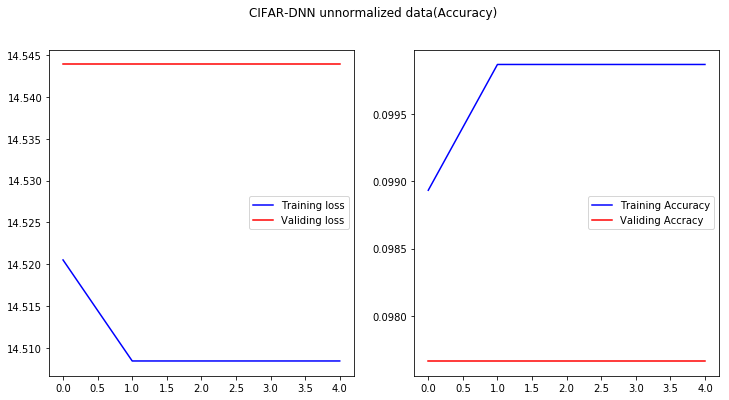

```python
# ====== train FNN on CIFAR ====== #
train_and_test_dnn(x_train, y_train, x_valid, y_valid, x_test, y_test,
    "CIFAR-DNN unnormalized data")
```

### Normalizing the data

It is notable that the CIFAR-10 provided features in **uint8** data type, and the intensity of each pixel is from 0 to 255. The big values would magnify the backpropagated gradients values, as a results, the weights are moving around so fast that they cannot reach a better solution.

We normalize the values in range **[0., 1.]**. Then training the network again

```
_________________________________________________________________
Layer (type)                 Output Shape              Param #
=================================================================
reshape_8 (Reshape)          (None, 3072)              0
_________________________________________________________________
dense_19 (Dense)             (None, 256)               786688
_________________________________________________________________
dropout_10 (Dropout)         (None, 256)               0
_________________________________________________________________
dense_20 (Dense)             (None, 10)                2570
=================================================================
Total params: 789,258
Trainable params: 789,258
Non-trainable params: 0
_________________________________________________________________
Train on 7500 samples, validate on 3000 samples
Test loss: 1.93693001715
Test accuracy: 0.303111111164
```

```
<keras.callbacks.History at 0x15eec2750>
```

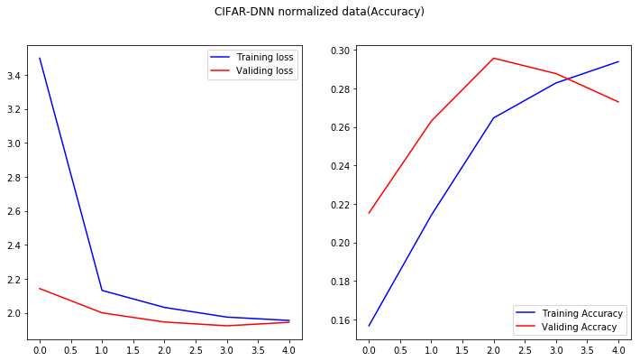

```python
# ====== fail to converge, normalize the data ====== #
x_train = x_train.astype('float32')
x_train /= 255.
x_aug = x_aug.astype('float32')
x_aug /= 255.
x_valid = x_valid.astype('float32')
x_valid /= 255.
x_test = x_test.astype('float32')
x_test /= 255.
train_and_test_dnn(x_train, y_train, x_valid, y_valid, x_test, y_test,
    "CIFAR-DNN normalized data")
```

The network converged, and we get significant improvement, but it is nothing compare to *>90%* on MNIST dataset. Could we get a better model for this task?

### Convolutional Neural Network for image recognition

Creating convolutional neural network in keras is straight forward:

```python
def train_and_test_cnn(x_train, y_train,
                       x_valid, y_valid,
                       x_test, y_test,
                       title):
    model = Sequential()
    model.add(Conv2D(32, (3, 3), padding='same',
                     input_shape=x_train.shape[1:],
                     activation='relu', data_format='channels_last'))
    model.add(MaxPooling2D(pool_size=(2, 2)))
    model.add(Conv2D(64, (3, 3),
                     activation='relu', data_format='channels_last'))
    model.add(MaxPooling2D(pool_size=(2, 2)))
    model.add(Flatten())
    model.add(Dense(128, activation='relu'))
    model.add(Dropout(0.5))
    model.add(Dense(10, activation='softmax'))

    model.summary()

    model.compile(loss='categorical_crossentropy',
                  optimizer=RMSprop(),
                  metrics=['accuracy'])
    history = model.fit(x_train, y_train,
                        batch_size=128,
                        epochs=5,
                        verbose=1,
                        validation_data=(x_valid, y_valid))
    # ====== plot history ====== #
    plt.figure()
    plt.subplot(1, 2, 1)
    train_loss = history.history['loss']
    val_loss = history.history['val_loss']
    plt.plot(train_loss, color='b', label='Training loss')
    plt.plot(val_loss, color='r', label="Validing loss")
    plt.suptitle(title + "(cross-entropy loss)")
    plt.legend()
    plt.subplot(1, 2, 2)
    train_loss = history.history['acc']
    val_loss = history.history['val_acc']
    plt.plot(train_loss, color='b', label='Training Accuracy')
    plt.plot(val_loss, color='r', label="Validing Accracy")
    plt.suptitle(title + "(Accuracy)")
    plt.legend()
    # ====== final evaluation ====== #
    score = model.evaluate(x_test, y_test, verbose=0)
    print('Test loss:', score[0])
    print('Test accuracy:', score[1])
    return history
```

We again train the network on normalized CIFAR-10, but we also try it on augmented CIFAR-10

```
_________________________________________________________________
Layer (type)                 Output Shape              Param #
=================================================================
conv2d_5 (Conv2D)            (None, 32, 32, 32)        896
_________________________________________________________________
max_pooling2d_5 (MaxPooling2 (None, 16, 16, 32)        0
_________________________________________________________________
conv2d_6 (Conv2D)            (None, 14, 14, 64)        18496
_________________________________________________________________
max_pooling2d_6 (MaxPooling2 (None, 7, 7, 64)          0
_________________________________________________________________
flatten_3 (Flatten)          (None, 3136)              0
_________________________________________________________________
dense_21 (Dense)             (None, 128)               401536
_________________________________________________________________
dropout_11 (Dropout)         (None, 128)               0
_________________________________________________________________
dense_22 (Dense)             (None, 10)                1290
=================================================================
Total params: 422,218
Trainable params: 422,218
Non-trainable params: 0
_________________________________________________________________
Train on 7500 samples, validate on 3000 samples
Test loss: 1.43870938947
Test accuracy: 0.494666666667
```

```
<keras.callbacks.History at 0x148fe5e50>
```

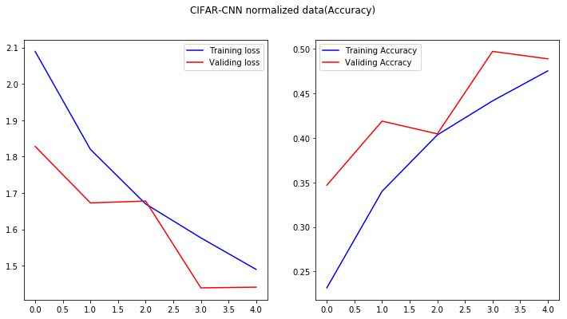

```python
train_and_test_cnn(x_train, y_train, x_valid, y_valid, x_test, y_test,
    "CIFAR-CNN normalized data")
```

Big improvement! Note our CNN network only need half of the amount of the parameters (~400,000) compared to fully connected network (~800,000), it demonstrate the efficiency of this network in learning image presentation.

```
_________________________________________________________________
Layer (type)                 Output Shape              Param #
=================================================================
conv2d_7 (Conv2D)            (None, 32, 32, 32)        896
_________________________________________________________________
max_pooling2d_7 (MaxPooling2 (None, 16, 16, 32)        0
_________________________________________________________________
conv2d_8 (Conv2D)            (None, 14, 14, 64)        18496
_________________________________________________________________
max_pooling2d_8 (MaxPooling2 (None, 7, 7, 64)          0
_________________________________________________________________
flatten_4 (Flatten)          (None, 3136)              0
_________________________________________________________________
dense_23 (Dense)             (None, 128)               401536
_________________________________________________________________
dropout_12 (Dropout)         (None, 128)               0
_________________________________________________________________
dense_24 (Dense)             (None, 10)                1290
=================================================================
Total params: 422,218
Trainable params: 422,218
Non-trainable params: 0
_________________________________________________________________
Train on 22500 samples, validate on 3000 samples
Test loss: 1.308014248
Test accuracy: 0.523555555609
```

```
<keras.callbacks.History at 0x14a75a4d0>
```

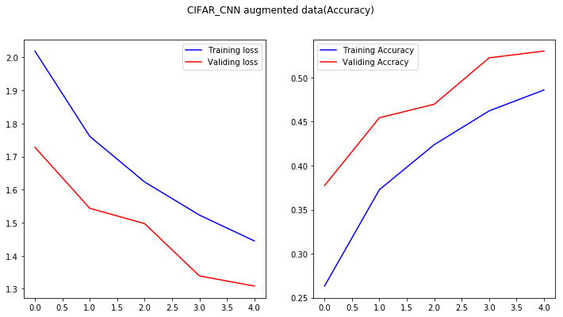

```python
train_and_test_cnn(x_aug, y_aug, x_valid, y_valid, x_test, y_test,
    "CIFAR_CNN augmented data")
```